# Welcome to Introduction to AI Applications!

Lecture 01: Introduction

Danilo Freire

danilo.freire@emory.edu

Department of Data and Decision Sciences  
Emory University

# Welcome to DATASCI 101! 🎉

## Lecture overview

### Today’s agenda

- Hello and welcome!
- Instructor and TAs
- Motivation and course overview
- Assignments and grading
- Course logistics

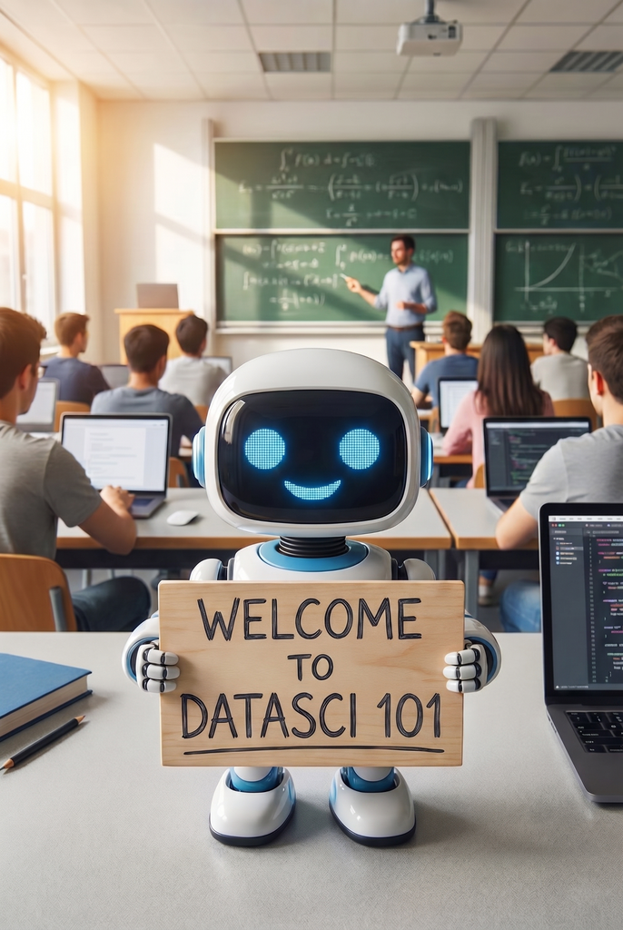

## Course materials

### Important links

Course website: https://danilofreire.github.io/datasci101

Course repository: https://github.com/danilofreire/datasci101

The website is the main hub for your learning, while the assignments and group work files will be available on the repository

We will use Canvas for course administration, including submitting assignments, accessing grades, and receiving announcements

Please take some time to get to know both platforms, and reach out if you have any questions

**Note**

Please remember to check the course repository regularly for updates and announcements!

# Nice to meet you! 😊

## Instructor

### A bit about me

danilo.freire@emory.edu

https://danilofreire.github.io/

https://github.com/danilofreire/

Visiting Assistant Professor in the [Department of Data and Decision Sciences](https://quantitative.emory.edu)

MA from the Graduate Institute Geneva, PhD from King’s College London, Postdoc at Brown University, Senior Lecturer at the University of Lincoln, UK

Research interests: computational social science, experimental methods, policy evaluation, political violence, organised crime

## What about you? (time permitting!)

- Now it’s your turn! 😉
- Please introduce yourself! 👋
- Tell us your name, your major, and what would you like to learn in this course!

## My teaching philosophy

- I love teaching and aim to make learning fun
- Classes where students participate are the best!
- Hands-on activities help you learn better
- I am always available to help and answer questions. And I mean it!
- Your feedback helps me improve my teaching. Please let me know what is working and what is not 😉

## Teaching assistants

- The teaching assistants for this course will be announced soon
- They will be available to help you with assignments, quizzes, and any questions you may have about the course material
- We are all here to help you! So feel free to ask questions during class, office hours, or via email 😃

## Office hours

### What for and what not for

- What office hours are meant for:
  - Applying tools in practice
  - Discussion of issues related to the assignments
  - Boosting your knowledge of AI and data science more generally
- What these sessions are not meant for:
  - Summarising lecture content
  - Solving the assignments for you

## Class etiquette

- Learning a new topic can be tough and push you out of your comfort zone. If the course pace is too fast, let me know. I expect your commitment, but I do not want anyone to fail
- You are all keen on AI, but your backgrounds may vary. That is great! Some sessions might be more engaging than others. If you are bored, help others or explore additional resources (we have plenty!)
- Please be respectful to each other
- Ask questions whenever you need to!

[figure not shown]

## Learning objectives

By the end of this course, you will be able to:

- Explain the main ideas behind contemporary AI systems in plain language
- Identify common failure modes of AI systems and the data issues that cause them
- Read and assess claims about AI in news articles, product pages and policy documents
- Design a small, realistic plan for an AI application, including data needs, evaluation, and a basic harm-mitigation strategy
- Reflect critically on ethical, legal and social questions raised by AI deployment

## Course overview

| Module | Topic | Key Questions |
| --- | --- | --- |
| 0 | Orientation | What is AI? What will we learn? |
| 1 | AI Design | How are AI systems built? |
| 2 | Perception | How do machines read, write, see and hear? |
| 3 | RAG & Pipelines | How do we make AI reliable? |
| 4 | Ethics & Bias | What can go wrong? |
| 5 | Policy & Impact | How is AI regulated? |
| 6 | Applications | Real-world uses and limits |

## Logistics

### Course information

- Syllabus: Available on our [course repository](https://github.com/danilofreire/datasci101/blob/main/syllabus.pdf) and [website](https://danilofreire.github.io/datasci101/syllabus.html). The course is designed to be self-contained
- The syllabus and the website includes links to the slides we will use in class, along with recommended readings, and problem sets
- I may update the slides as the course progresses, so please check the website regularly for updates
- Schedule: Lectures are on Tuesdays and Thursdays from 2:30 to 3:20 pm in [White Hall 206](https://maps.app.goo.gl/gynyTUkKqJ7meGjm8)
- Office Hours: We’re always happy to help. Please reach out to the TAs or me via email to schedule a time
- Materials (recap): All course materials will be available on:
  - Course repository: https://github.com/danilofreire/datasci101
  - Course website: https://danilofreire.github.io/datasci101
  - Canvas

## Assignments

### How you will be graded

- Problem sets: Ten of them, due on Thursdays at 11:59 pm (50%)
- In-class quizzes: Five of them (30%)
- Final project: Due on the last day of class (20%)
- Late policy: 10% off per day late
- Collaboration: You can discuss assignments with your classmates, but you must write your own code and submit your own work. AI is allowed, but you must disclose its use and ensure you understand the output
- Academic integrity: Please refer to the syllabus for the university’s policy on academic integrity

# Motivation: What is AI anyway? 🤖

## What is AI?

- A simple definition: Artificial Intelligence (AI) is a branch of computer science focused on creating systems capable of performing tasks that typically require human intelligence
- These tasks include learning, reasoning, problem-solving, perception, language understanding, and many more!
- AI can be classified into three main categories:
  - Narrow AI: Designed for specific tasks (e.g., virtual assistants, recommendation systems)
  - General AI: Hypothetical systems that possess human-like intelligence across a wide range of tasks
  - Superintelligent AI: Surpasses human intelligence in all aspects (still theoretical)
- AI is powered by various techniques, including machine learning, deep learning, and natural language processing

## AI taxonomy

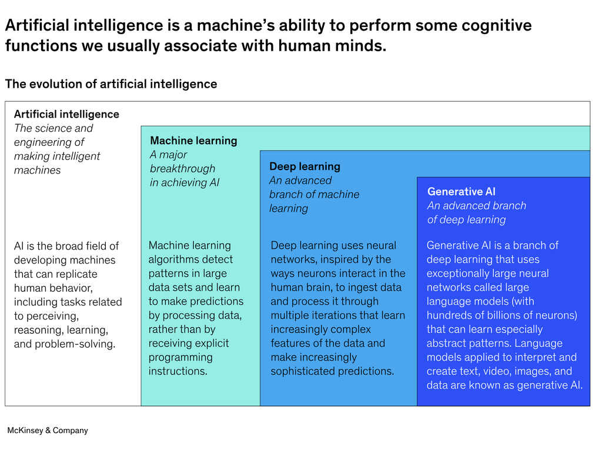

Source: [McKinsey & Company (2024)](https://www.mckinsey.com/featured-insights/mckinsey-explainers/what-is-ai)

## Why should you care about AI?

- AI already impacts many aspects of our daily lives:
  - Virtual assistants (e.g., Siri, Alexa)
  - Recommendation systems (e.g., Netflix, Amazon)
  - Dating apps (e.g., Tinder, Bumble)
  - Social media algorithms (e.g., Facebook, Instagram)
- AI is transforming industries:
  - Healthcare (e.g., diagnostics, personalised medicine)
  - Finance (e.g., fraud detection, algorithmic trading)
  - Transportation (e.g., autonomous vehicles, route optimisation)
  - Education (e.g., personalised learning, 24/7 tutoring)
- Whether AI lives up to the hype or not, it is already changing how many of these industries work

[figure not shown]

## Key questions we’ll explore

- What can AI actually do vs. what’s hype?
  - Can AI truly think or is it just pattern matching?
  - Why does AI sometimes give wrong answers?
  - What can and cannot be automated?
- Why do AI systems fail?
  - What happens when training data doesn’t represent everyone?
- How does data affect AI behaviour?
  - Garbage in, garbage out
  - Who decides what counts as “correct” data?
- What are the ethical implications?
  - Should AI make life-or-death decisions?
  - Who’s responsible when AI makes a mistake?
- How should we regulate AI?
  - Innovation vs. safety trade-offs
  - What role should civil society play in governing AI?

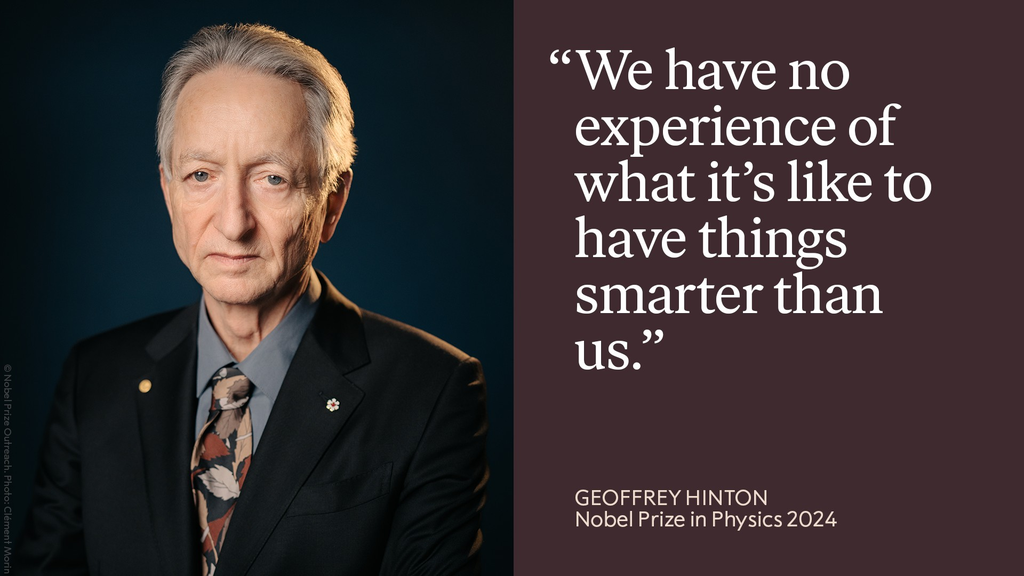

[figure not shown]

## AI benchmarks and human performance

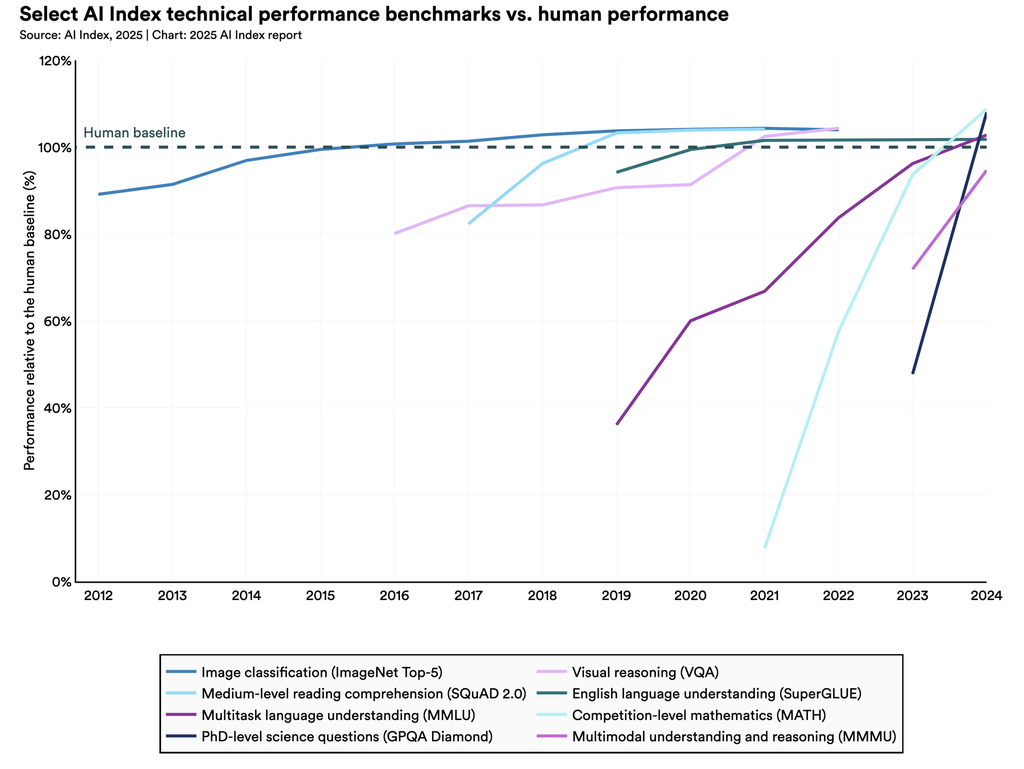

Source: [Artificial Intelligence Index Report (2025)](https://hai.stanford.edu/ai-index/2025-ai-index-report)

## True or false?

- AI understands language like humans do
  - False! AI predicts likely next tokens (what are they?)
- AI will replace all jobs
  - Probably not. AI transforms jobs more than it eliminates them
- AI hallucinations are easy to spot
  - False! AI sometimes confidently states incorrect information, and it’s not always obvious
- We can test AI systems by deliberately trying to trick them
  - True! This is called adversarial testing or red-teaming
- AI systems that learn without any human labels exist
  - True! This is called unsupervised learning, and it finds hidden patterns automatically
- AI systems can explain why they made a particular decision
  - False! Many AI systems are “black boxes”, that is, we don’t know for sure how they came up with their answers
- The order of words in a sentence affects how AI processes it
  - True! Attention mechanisms let models weigh the importance of different words
- The same AI model can be fine-tuned for many different tasks
  - True! This is one of the most powerful aspects of modern AI

## Next class

- Topic: A brief history of AI and the recent shift
- What we’ll cover:
  - From symbolic approaches to data-driven learning
  - The transformer architecture explained in plain language
  - How we got from early AI to ChatGPT
- Main takeaway: You can’t make sense of ChatGPT without knowing the 70 years of ideas that led to it
- Preparation: Read the assigned articles on AI history and transformers

[figure not shown]

Suggested video: [The AI Doc](https://www.youtube.com/watch?v=yvq-jYira9I)

# … and that’s all for today! 🎉